# Practicing Model Selection

Lexi

10/6/2021

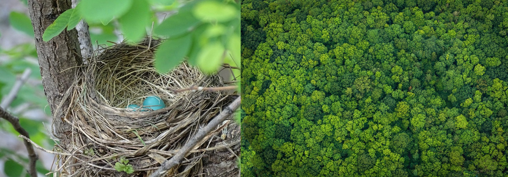

## Example 1: Tree Stand Variables Predict Tree-Nesting Bird Richness

First, let’s import the dataset.

```r
bird_abundance <- read.csv("~/Desktop/Analytics/model_selection_practice/model_selection_practice/data/bird_abundance_data.csv")
```

The data includes four response variables; ground-nesting, cavity-nesting, tree-nesting and shrub-nesting bird species richness. The data includes five predictor variables: sapling species richness, tree stand age, tree species richness, percent woody debris understory, and number of snags present.

First, we need to check for colinearity among our predictor variables

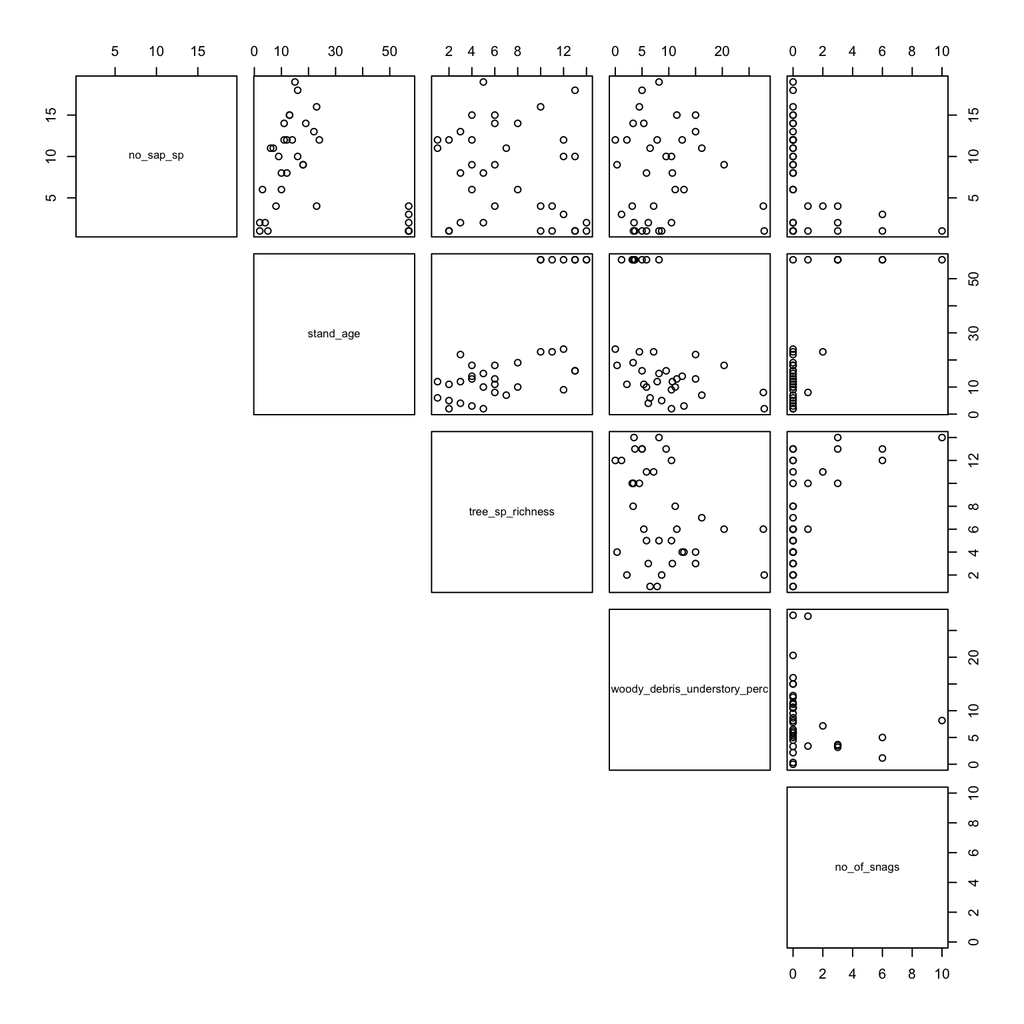

```r
pairs(bird_abundance[,6:10], lower.panel = NULL)
```

For the most part, everything looks unrelated which is represented by the “gun-shot” splatter distribution of points.

One very important thing you should do next is change the global options for how R functions handle missing data. By making this change, a function will not work if data are missing. This is required if you use the `dredge` function for exploratory data analysis.

```r
# change na. action
options(na.action = "na.fail")
```

Now we are ready! Let’s fit some candidate models that could explain variation in bird species richness. I picked these randomly, but normally you would base these off of hypotheses.

```r
#First, fit 4 candidate linear models to explain variation in density
mod1<-lm(tree_bird_sp_richness~stand_age+tree_sp_richness, data = bird_abundance)
mod2<-lm(tree_bird_sp_richness~woody_debris_understory_perc+tree_sp_richness, data = bird_abundance)
mod3<-lm(tree_bird_sp_richness~no_of_snags+tree_sp_richness, data = bird_abundance)
mod4<-lm(tree_bird_sp_richness~stand_age+no_of_snags, data = bird_abundance)
```

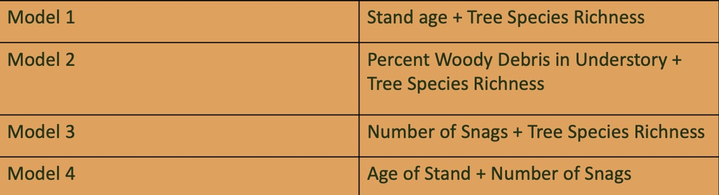

We can now use the `model.sel` function to conduct model selection. The default model selection criteria is Akaike’s information criteria (AIC) with small sample bias adjustment, AIC<sub>c</sub>. Here we’ll create an object `out.put` that contains all of the model selection information.

```r
# use the model.sel function to conduct model selection
# and put output into object out.put
out.put<-model.sel(mod1,mod2,mod3,mod4)
out.put
```

```
## Model selection table
##       (Int)  stn_age tre_sp_rch wdy_dbr_und_prc no_of_sng             family df
## mod1 10.930 -0.08881    0.21190                           gaussian(identity)  4
## mod4 11.750 -0.05483                             -0.02501 gaussian(identity)  4
## mod3 10.580             0.04623                  -0.42680 gaussian(identity)  4
## mod2  9.735            -0.01966          0.1034           gaussian(identity)  4
##       logLik  AICc delta weight
## mod1 -76.903 163.1  0.00  0.803
## mod4 -78.503 166.3  3.20  0.162
## mod3 -80.424 170.1  7.04  0.024
## mod2 -81.117 171.5  8.43  0.012
## Models ranked by AICc(x)
```

```r
# create a confidence set of models using the subset function
# select models with delta AICc less than 5
# IMPORTANT: Weights have been renormalized!!
subset(out.put, delta <5)
```

```
## Model selection table
##      (Int)  stn_age tre_sp_rch no_of_sng             family df  logLik  AICc
## mod1 10.93 -0.08881     0.2119           gaussian(identity)  4 -76.903 163.1
## mod4 11.75 -0.05483             -0.02501 gaussian(identity)  4 -78.503 166.3
##      delta weight
## mod1   0.0  0.832
## mod4   3.2  0.168
## Models ranked by AICc(x)
```

```r
# select models using Royall's 1/8 rule for strength of evidence
#https://www.stat.fi/isi99/proceedings/arkisto/varasto/roya0578.pdf
# IMPORTANT: Weights have been renormalized!!
subset(out.put, 1/8 < weight/max(out.put$weight))
```

```
## Model selection table
##      (Int)  stn_age tre_sp_rch no_of_sng             family df  logLik  AICc
## mod1 10.93 -0.08881     0.2119           gaussian(identity)  4 -76.903 163.1
## mod4 11.75 -0.05483             -0.02501 gaussian(identity)  4 -78.503 166.3
##      delta weight
## mod1   0.0  0.832
## mod4   3.2  0.168
## Models ranked by AICc(x)
```

Not much different than delta < 5 above. Let’s try another criteria based on the cumulative sum of the model weights.

```r
# select models 95% cumulative weight criteria
# IMPORTANT: Weights have been renormalized!!
subset(out.put, cumsum(out.put$weight) <= .95)
```

```
## Model selection table
##      (Int)  stn_age tre_sp_rch             family df  logLik  AICc delta weight
## mod1 10.93 -0.08881     0.2119 gaussian(identity)  4 -76.903 163.1     0      1
## Models ranked by AICc(x)
```

```r
# coerce the object out.put into a data frame
# elements 6-10 in out.put have what we want
sel.table<-as.data.frame(out.put)[6:10]
sel.table
```

```
##                  family df    logLik     AICc    delta
## mod1 gaussian(identity)  4 -76.90252 163.0954 0.000000
## mod4 gaussian(identity)  4 -78.50334 166.2970 3.201639
## mod3 gaussian(identity)  4 -80.42365 170.1376 7.042265
## mod2 gaussian(identity)  4 -81.11653 171.5234 8.428011
```

```r
# a little clean-up, lets round things a bit
sel.table[,2:3]<- round(sel.table[,2:3],2)
sel.table[,4:5]<- round(sel.table[,4:5],3)
sel.table
```

```
##                  family df logLik    AICc delta
## mod1 gaussian(identity)  4 -76.90 163.095 0.000
## mod4 gaussian(identity)  4 -78.50 166.297 3.202
## mod3 gaussian(identity)  4 -80.42 170.138 7.042
## mod2 gaussian(identity)  4 -81.12 171.523 8.428
```

```r
# that’s better
```

```r
## lets be sure to put the model names in a column
sel.table$Model<-rownames(sel.table)

# replace Model name with formulas little tricky so be careful

# let's see what is in there
sel.table
```

```
##                  family df logLik    AICc delta Model
## mod1 gaussian(identity)  4 -76.90 163.095 0.000  mod1
## mod4 gaussian(identity)  4 -78.50 166.297 3.202  mod4
## mod3 gaussian(identity)  4 -80.42 170.138 7.042  mod3
## mod2 gaussian(identity)  4 -81.12 171.523 8.428  mod2
```

The **relative importance of individual parameters** can also be examined using the model weights. Here, the Akaike weights for each model that contains the parameter of interest are summed. These have been defined as importance weights and you can obtain them from a `model.sel` object using the “importance” function.

```r
# Importance weights for individual predictor variables
# calculated using the importance function
importance(out.put)
```

```
##                      stand_age tree_sp_richness no_of_snags
## Sum of weights:      0.96      0.84             0.19
## N containing models:    2         3                2
##                      woody_debris_understory_perc
## Sum of weights:      0.01
## N containing models:    1
```

```r
# Model average using all candidate models, always use revised.var = TRUE
MA.ests<-model.avg(out.put, revised.var = TRUE)
MA.ests
```

```
##
## Call:
## model.avg(object = out.put, revised.var = TRUE)
##
## Component models:
## '12' '14' '24' '23'
##
## Coefficients:
##        (Intercept)   stand_age tree_sp_richness no_of_snags
## full      11.03961 -0.08014650        0.1709494 -0.01417607
## subset    11.03961 -0.08310451        0.2039706 -0.07637182
##        woody_debris_understory_perc
## full                    0.001227601
## subset                  0.103448383
```

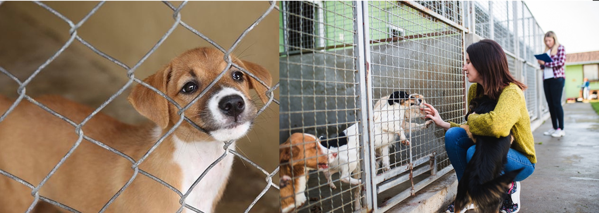

## Example 2: Dog Length of Stay in Shelter

import data

```r
dog <- read.csv("~/Desktop/Analytics/model_selection_practice/model_selection_practice/data/dog.csv")
```

The data includes one response variable; length of stay in shelter. The data includes five predictor variables: amount of tail wagging, amount of barking, time spent at the front of the kennel, time spent at the back of the kennel, and size of dog (ranked 1 and up, with 1 being smallest).

First, we need to check for colinearity among our predictor variables

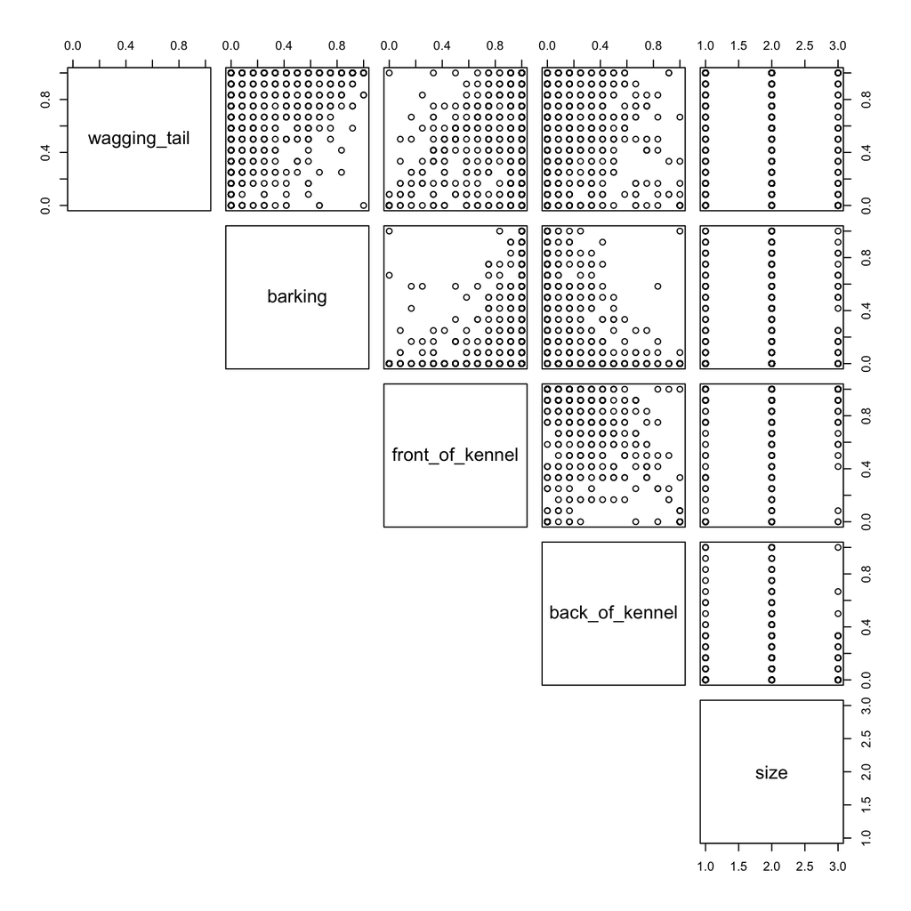

```r
pairs(dog[,2:6], lower.panel = NULL)
```

For the most part, everything looks unrelated which is displayed by the “gun-shot” splatter distribution of points.

One very important thing you should do next is change the global options for how R functions handle missing data. By making this change, a function will not work if data are missing. This is required if you use the `dredge` function for exploratory data analysis.

```r
# change na. action
options(na.action = "na.fail")
```

Now we are ready! Let’s fit some candidate models that could explain variation in kennel length of stay. I picked these randomly, but normally you would base these off of hypotheses.

```r
#First, fit 4 candidate linear models to explain variation in density
dog_mod1<-lm(length_of_stay~back_of_kennel+barking, data = dog)
dog_mod2<-lm(length_of_stay~wagging_tail+front_of_kennel, data = dog)
dog_mod3<-lm(length_of_stay~size+front_of_kennel, data = dog)
dog_mod4<-lm(length_of_stay~size, data = dog)
```

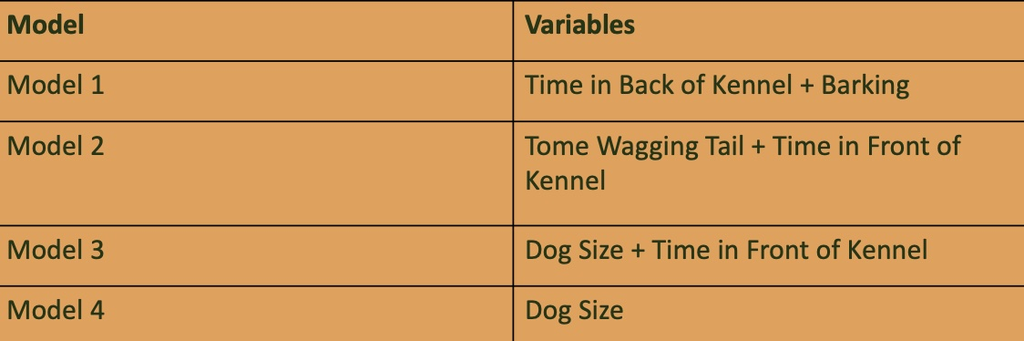

We can now use the `model.sel` function to conduct model selection. The default model selection criteria is Akaike’s information criteria (AIC) with small sample bias adjustment, AIC<sub>c</sub>. Here we’ll create an object `out.put` that contains all of the model selection information.

```r
# use the model.sel function to conduct model selection
# and put output into object out.put
dog_out.put<-model.sel(dog_mod1,dog_mod2,dog_mod3,dog_mod4)
dog_out.put
```

```
## Model selection table
##          (Int) bck_of_knn    brk frn_of_knn wgg_tal   siz             family df
## dog_mod4 22.35                                      5.567 gaussian(identity)  3
## dog_mod3 23.20                      -0.9525         5.568 gaussian(identity)  4
## dog_mod1 32.60      7.044 -2.023                          gaussian(identity)  4
## dog_mod2 33.61                      -1.2970  0.8282       gaussian(identity)  4
##             logLik    AICc delta weight
## dog_mod4 -7620.163 15246.3  0.00    0.7
## dog_mod3 -7620.005 15248.0  1.69    0.3
## dog_mod1 -7631.875 15271.8 25.43    0.0
## dog_mod2 -7637.331 15282.7 36.35    0.0
## Models ranked by AICc(x)
```

The models are sorted from best (top) to worst (bottom). Looks like `dog_mod3` and `dog_mod4` are the best. `dog_mod3` looks at size and positioned at the front of the kennel, while `dog_mod4` looks at size only. Size only appears to be (0.7/0.3=2.3) two times more likely to be the best explanation (hypothesis) for variation in kennel length of stay than a combination of size and position at the front of the kennel.

```r
# create a confidence set of models using the subset function
# select models with delta AICc less than 5
# IMPORTANT: Weights have been renormalized!!
subset(dog_out.put, delta <5)
```

```
## Model selection table
##          (Int) frn_of_knn   siz             family df    logLik    AICc delta
## dog_mod4 22.35            5.567 gaussian(identity)  3 -7620.163 15246.3  0.00
## dog_mod3 23.20    -0.9525 5.568 gaussian(identity)  4 -7620.005 15248.0  1.69
##          weight
## dog_mod4    0.7
## dog_mod3    0.3
## Models ranked by AICc(x)
```

```r
# select models using Royall's 1/8 rule for strength of evidence
#https://www.stat.fi/isi99/proceedings/arkisto/varasto/roya0578.pdf
# IMPORTANT: Weights have been renormalized!!
subset(dog_out.put, 1/8 < weight/max(out.put$weight))
```

```
## Model selection table
##          (Int) frn_of_knn   siz             family df    logLik    AICc delta
## dog_mod4 22.35            5.567 gaussian(identity)  3 -7620.163 15246.3  0.00
## dog_mod3 23.20    -0.9525 5.568 gaussian(identity)  4 -7620.005 15248.0  1.69
##          weight
## dog_mod4    0.7
## dog_mod3    0.3
## Models ranked by AICc(x)
```

No difference than delta < 5 above. Let’s try another criteria based on the cumulative sum of the model weights.

```r
# select models 95% cumulative weight criteria
# IMPORTANT: Weights have been renormalized!!
subset(dog_out.put, cumsum(out.put$weight) <= .95)
```

```
## Model selection table
##          (Int)   siz             family df    logLik    AICc delta weight
## dog_mod4 22.35 5.567 gaussian(identity)  3 -7620.163 15246.3     0      1
## Models ranked by AICc(x)
```

```r
# coerce the object out.put into a data frame
# elements 6-10 in out.put have what we want
dog.sel.table<-as.data.frame(dog_out.put)[8:12]
dog.sel.table
```

```
##          df    logLik     AICc     delta       weight
## dog_mod4  3 -7620.163 15246.34  0.000000 6.999479e-01
## dog_mod3  4 -7620.005 15248.03  1.694114 3.000500e-01
## dog_mod1  4 -7631.875 15271.77 25.432303 2.101412e-06
## dog_mod2  4 -7637.331 15282.68 36.345237 8.970112e-09
```

```r
# a little clean-up, lets round things a bit
dog.sel.table[,2:3]<- round(dog.sel.table[,2:3],2)
dog.sel.table[,4:5]<- round(dog.sel.table[,4:5],3)
dog.sel.table
```

```
##          df   logLik     AICc  delta weight
## dog_mod4  3 -7620.16 15246.34  0.000    0.7
## dog_mod3  4 -7620.01 15248.03  1.694    0.3
## dog_mod1  4 -7631.87 15271.77 25.432    0.0
## dog_mod2  4 -7637.33 15282.68 36.345    0.0
```

```r
# that’s better
```

```r
## lets be sure to put the model names in a column
dog.sel.table$Model<-rownames(dog.sel.table)

# replace Model name with formulas little tricky so be careful
#for(i in 1:nrow(dog.sel.table)) dog.sel.table$Model[i]<- as.character(formula(paste(dog.sel.table$Model[i])))[3]

# let's see what is in there
dog.sel.table
```

```
##          df   logLik     AICc  delta weight    Model
## dog_mod4  3 -7620.16 15246.34  0.000    0.7 dog_mod4
## dog_mod3  4 -7620.01 15248.03  1.694    0.3 dog_mod3
## dog_mod1  4 -7631.87 15271.77 25.432    0.0 dog_mod1
## dog_mod2  4 -7637.33 15282.68 36.345    0.0 dog_mod2
```

[figure not shown]